# HW 10 - advMCMC

Eunchong Kang

04/04/2022

# MCMC extension of HW 6

We would like to simulate from the posterior distribution of parameter $\boldsymbol{\theta} = (\pi,\lambda)$ pertaining to the fishing dataset and zero-inflated poisson model described in HW 6, assuming $\pi$ has a Unif(0,1) prior, and $\lambda$ has a Gamma(2,2) prior (shape and scale = 2). The joint posterior can be written as $f(\pi,\lambda | \boldsymbol{y}) \propto f(\boldsymbol{y} | \pi, \lambda)f(\pi,\lambda) = f(\boldsymbol{y} | \pi, \lambda)f(\pi)f(\lambda)$, where $f(\boldsymbol{y} | \pi,\lambda)$ is the likelihood give in HW 6 except with $\lambda$ unknown, $f(\pi)$ is the specified prior for $\pi$, and $f(\lambda)$ is the specified prior for $\lambda$.

Implement a MH random walk procedure to sample from the joint posterior of $\boldsymbol{\theta} = (\pi,\lambda)$. You do not necessarily need to do a change of variable for $\pi$ or $\lambda$, however for proposals that exceed the boundaries of the parameter space of either parameter, the posterior for the propsal should be set = 0 (MH ratio = 0). You may want to consider a narrower random walk variance in such as setting as well.

```r
### HELPER FUNCTIONS
# log prior for lambda, fill in
lplambda <- function(lambda){
        lplambda <- dgamma(lambda, shape=2, scale=2, log=TRUE)

        return(lplambda)
}

# log prior for pi, fill in
lppi <- function(pi){
        lppi <- dunif(pi, min=0, max=1, log=TRUE)

        return(lppi)
}

# logit function
logit <- function(pi){
        u <- log(pi/(1-pi))

        return(u)
}


# inverse logit function
# Change of variable for pi
inv.logit <- function(u){
        pi <- exp(u)/(1+exp(u))

        return(pi)
}

# Functions of producing a random walk.
# unif(-1,1) for u (and pi)
r.walk_u <- function(){
        r.walk <- runif(1, min=-1, max=1)

        return(r.walk)
}
# normal(0,0.25) for lambda
r.walk_lambda <- function(){
        r.walk <- rnorm(1, mean=0, sd=0.001)

        return(r.walk)
}


# Function of producing candidate
# x is a vector with length 2
h.sim <- function(x, theta){
        if (theta == "u"){
                x <- x + r.walk_u()
        }

        if (theta == "lambda"){
                x <- x + r.walk_lambda()
        }

        return(x)
}

h.sim(1, "u")
```

```
## [1] 0.05380527
```

```r
# returns ll, or log f(y|lambda, pi)
# compute given y and ny from table
# Here, x is u (not pi)
ll <- function(y, ny, x){
  pi = x[1]
  lambda = x[2]

  # when y = 0
  y0 <- ny[which(y==0)]*log(pi + (1-pi)*exp(-lambda))

  # when y > 0 (y greater then 0)
  ygt0 <- sum(ny[which(y!=0)] * log((1-pi)*dpois(y[which(y!=0)], lambda=lambda)))

  # log-Jacobian for pi and u
  #### 교수님 -log(pi*(1-pi))
  log_jacob <- -log(pi*(1-pi))

  # log-likelihood
  ll <- y0 + ygt0 + lplambda(lambda) + lppi(pi) + log_jacob

  return(ll)
}



# MH ratio
# Hint; since h symmetric, proposal density cancels out of ratio
R <- function(y, ny, x, xt){
        logR <- ll(y,ny,x) - ll(y,ny,xt)
        R <- exp(logR)

        return(R)
}
```

Now start the main code for the sampler

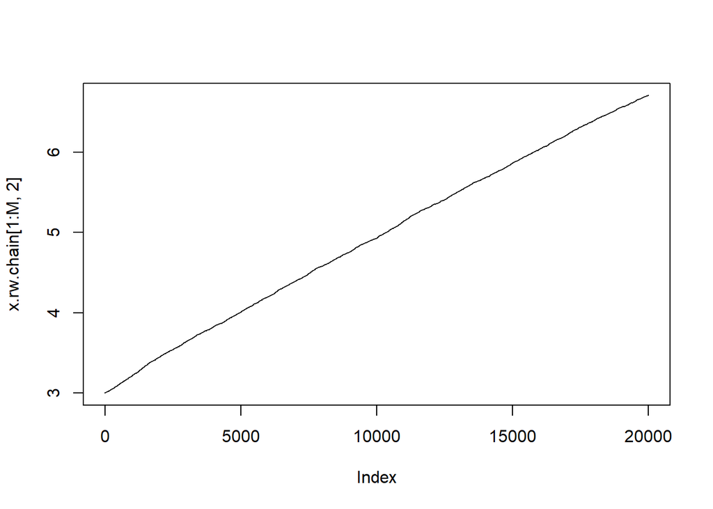

```r
# set the seed
set.seed(1)
# data fro HW 6
y = 0:6
ny = c(3062, 587, 284, 103, 33, 4, 2)
# Set chain length
M = 20000
# initialize the chain vector (alpha, lambda)
x.rw.chain = matrix(0, M, 2)
colnames(x.rw.chain) = c("pi","lambda")
# Initialize chain with specified initial values
# alpha, lambda
x.rw.chain[1,] = c(0.3, 3)

# u vector
# u.rw.chain = matrix(0, M, 2)
# colnames(u.rw.chain) = c("u","lambda")
# u.rw.chain[1,] = c(logit(0.3), 3)

accept <- rep(0,2)

# now start chain
for(i in 1:(M - 1)) {
        # set the value at current iteration of the chain to variable xt
        xt <- x.rw.chain[i, ]

        # Metropolis-within-Gibbs
        # loop for pi and lambda

        # pi
                # set proposal equal to previous
                x <- xt

                # pi
                # change of variable
                u <- logit(x[1])

                # Update
                u <- u + r.walk_u()

                # Transform back to pi
                x[1] <- inv.logit(u)

                # Calculate MH ratio
                r <- min(R(y, ny, x, xt), 1)

                #
                keep <- rbinom(1,1,r)

                # if keep = 1, then set next iteration equal to then proposal
                if (keep == 1) {
                        x.rw.chain[i + 1, ] <- x

                        # reset xt
                        xt <- x

                        # update number of acceaptance
                        accept[1] <- accept[1] + 1
                } else{
                # otherwise, carry over value from the current iteration
                        x.rw.chain[i + 1, ] <- xt
                }



        # lambda
                # set proposal equal to previous
                x <- xt

                # Update
                random_walk_lambda <- r.walk_lambda()

                if (random_walk_lambda <= 0){
                        r <- 0
                } else {
                        x[2] <- x[2] + random_walk_lambda

                        # Calculate MH ratio
                        r <- min(R(y, ny, x, xt), 1)
                }
                        #
                        keep <- rbinom(1,1,r)

                        # if keep = 1, then set next iteration equal to then proposal
                        if (keep == 1) {
                                x.rw.chain[i + 1, ] <- x

                                # reset xt
                                xt <- x

                                # update number of acceaptance
                                accept[2] <- accept[2] + 1
                        } else{
                                # otherwise, carry over value from the current iteration
                                x.rw.chain[i + 1, ] <- xt
                        }


}
# print posterior means and diagnostic plots.  Comment on convergence

plot(x.rw.chain[1:M,2], type="l")
```

```r
accept/M
```

```
## [1] 0.06130 0.31265
```